# team

Jaeyeon Won, Alec Meyer

9/9/2020

## Reading in the Data Set

```r
#Reading in the data set
choco <- read.csv("https://raw.githubusercontent.com/xdaiISU/ds202materials/master/hwlabs/data/choco.csv")

#Information
str(choco)
```

```
## 'data.frame':    2312 obs. of  13 variables:
##  $ REF                 : int  2454 2458 2454 797 797 1015 1019 1011 1019 1011 ...
##  $ Company             : chr  "5150" "5150" "5150" "A. Morin" ...
##  $ Location            : chr  "U.S.A." "U.S.A." "U.S.A." "France" ...
##  $ Date                : int  2019 2019 2019 2012 2012 2013 2013 2013 2013 2013 ...
##  $ Bean_Origin         : chr  "Madagascar" "Dominican Republic" "Tanzania" "Peru" ...
##  $ Specific_Bean_Origin: chr  "Bejofo Estate, batch 1" "Zorzal, batch 1" "Kokoa Kamili, batch 1" "Peru" ...
##  $ Cocoa_Percent       : num  76 76 76 63 70 70 63 70 70 70 ...
##  $ Ingredients         : chr  "3- B,S,C" "3- B,S,C" "3- B,S,C" "4- B,S,C,L" ...
##  $ Characteristics1    : chr  "cocoa" "cocoa" "rich cocoa" "fruity" ...
##  $ Characteristics2    : chr  "blackberry" "vegetal" "fatty" "melon" ...
##  $ Characteristics3    : chr  "full body" "savory" "bready" "roasty" ...
##  $ Characteristics4    : chr  NA NA NA NA ...
##  $ Rating              : num  3.75 3.5 3.25 3.75 3.5 4 4 3.75 3.5 3.25 ...
```

## Investigation of the Distribution of Ratings

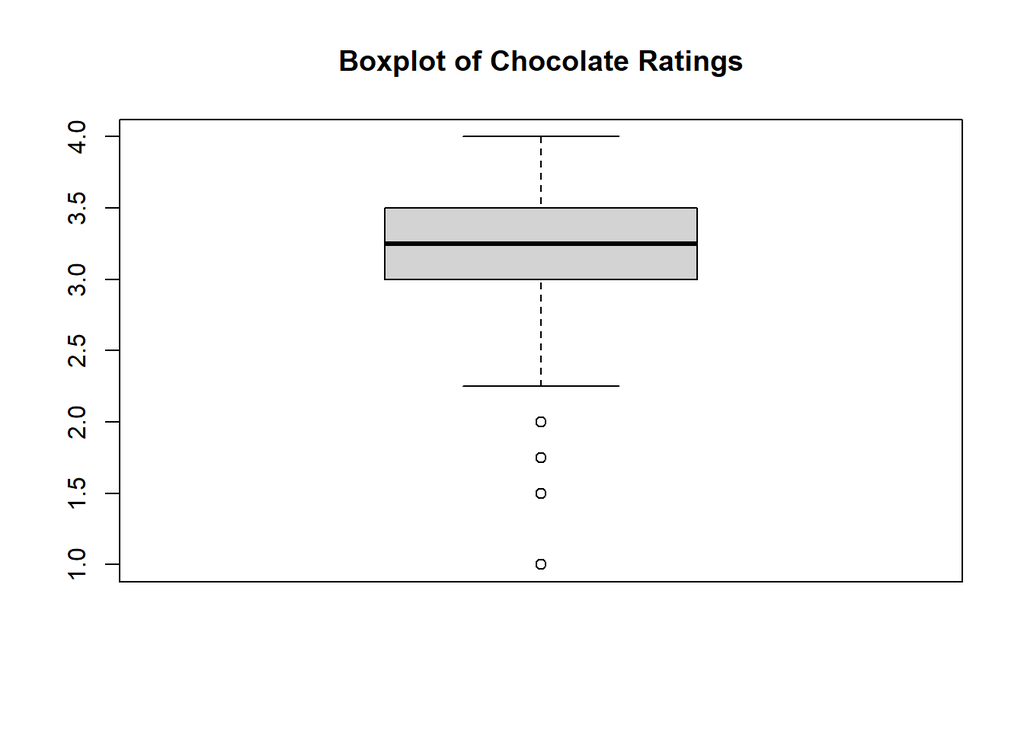

```r
#Boxplot
boxplot(choco$Rating, main="Boxplot of Chocolate Ratings")
```

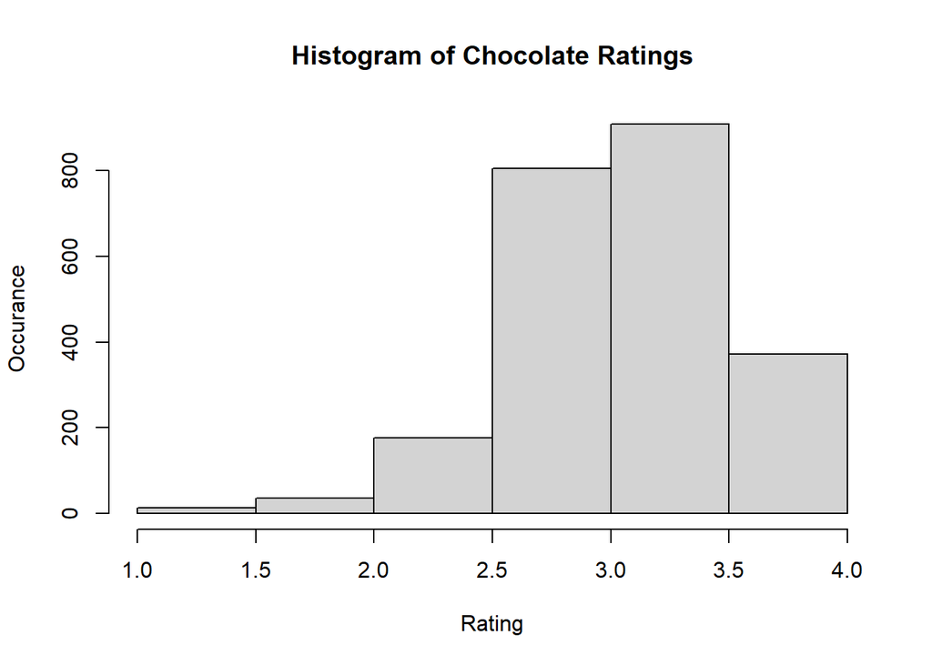

```r
#Histogram
hist(choco$Rating, breaks = 10, main="Histogram of Chocolate Ratings", xlab="Rating", ylab="Occurance")
```

Based on the histogram and boxplot, ratings are fairly left skewed resulting in higher than average ratings for the chocolates. The distribution is unimodal. We cannot clearly see in the histogram, but in the boxplot, there are multiple outliers below the ratings of 2.0.

## Investigation of the Relationship between Ratings and Cocoa Percent

```r
#Numerical Summary
#Subsetting
Unpleasant = choco[(choco$Rating >= 1.0) & (choco$Rating <= 1.9), ]
Disappointing = choco[(choco$Rating >= 2.0) & (choco$Rating <= 2.9), ]
Recommended = choco[(choco$Rating >= 3.0) & (choco$Rating <= 3.49), ]
HighlyRecommended = choco[(choco$Rating >= 3.5) & (choco$Rating <= 3.9), ]
Outstanding = choco[(choco$Rating >= 4.0) & (choco$Rating <= 5.0), ]
#Saving the average cocoa percent for each subset in a vector
mean_cocoa_percent = c(mean(Unpleasant$Cocoa_Percent),
                       mean(Disappointing$Cocoa_Percent),
                       mean(Recommended$Cocoa_Percent),
                       mean(HighlyRecommended$Cocoa_Percent),
                       mean(Outstanding$Cocoa_Percent))
levels = c("Unpleasant", "Disappointing", "Recommended", "HighlyRecommended", "Outstanding")
dataframe = data.frame(levels, mean_cocoa_percent)
dataframe
```

```
##              levels mean_cocoa_percent
## 1        Unpleasant           84.29412
## 2     Disappointing           72.31784
## 3       Recommended           71.56327
## 4 HighlyRecommended           71.12549
## 5       Outstanding           70.77451
```

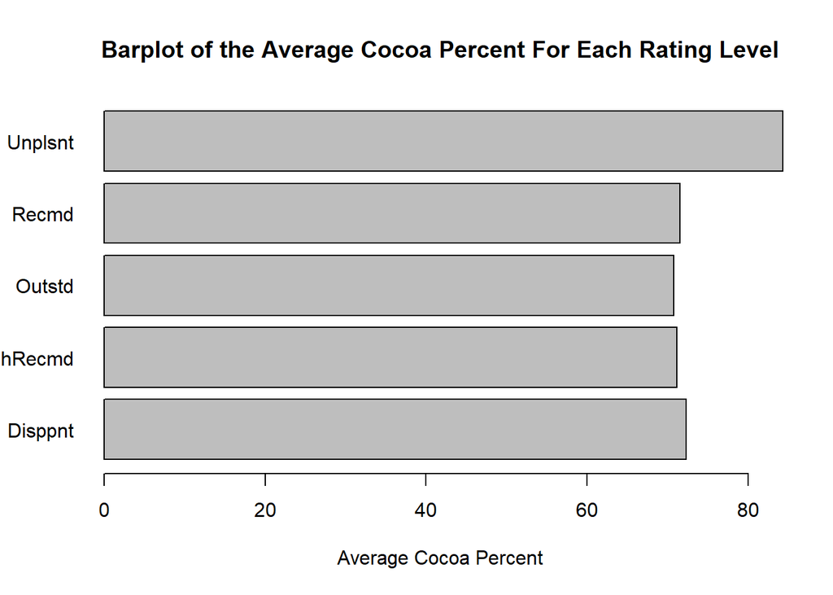

```r
#Graphical Summary
#Barplot
levels2 = c("Unplsnt", "Disppnt", "Recmd", "hRecmd", "Outstd")
barplot(dataframe$mean_cocoa_percent ~ levels2,
        main = 'Barplot of the Average Cocoa Percent For Each Rating Level',
        xlab = 'Average Cocoa Percent',
        ylab = '',
        horiz = TRUE,
        las = 1)
```

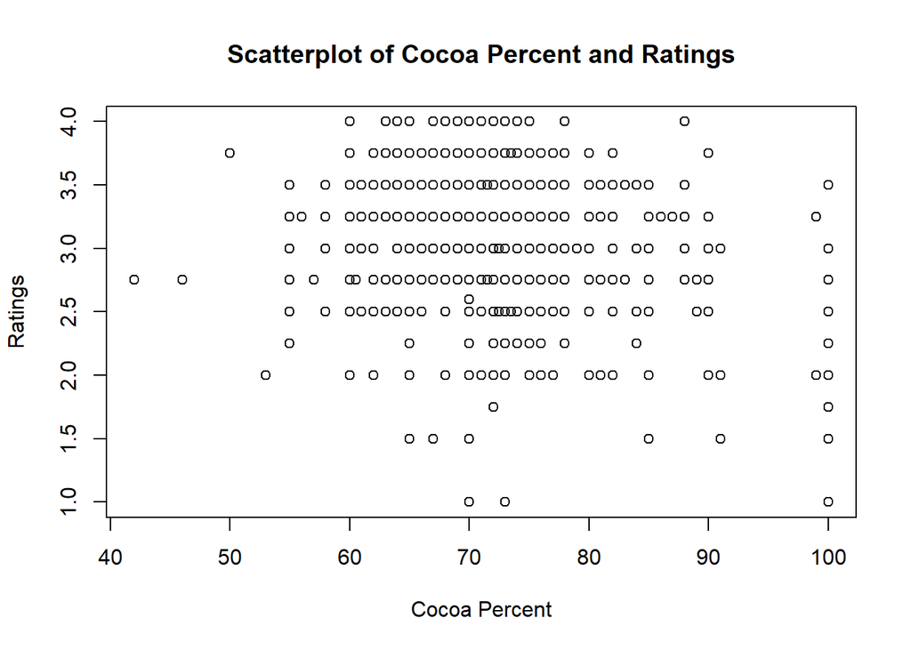

```r
#Scatterplot
plot(choco$Cocoa_Percent, choco$Rating,
     main = "Scatterplot of Cocoa Percent and Ratings",
     xlab = "Cocoa Percent", ylab = "Ratings")
```

Based on the numerical and graphical analysis of the mean cocoa percent for each rating level, we can see that the lower the ratings are, the higher the mean cocoa percent is.However, this pattern is not obvious in the scatter plot since Ratings is an ordinal variable.

## Investigation of Favorable and Unfavorable Characteristics

```r
library(dplyr)
#Favorable Characteristics
#Creating summaries
good_Characteristics = choco %>%
  select(Characteristics1, Rating) %>%
  group_by(Characteristics1) %>%
  summarise(Average_Rating = mean(Rating)) %>%
  arrange(desc(Average_Rating)) %>%
  top_n(10)
#Numerical summaries
good_Characteristics
```

```
## # A tibble: 11 x 2
##    Characteristics1         Average_Rating
##    <chr>                             <dbl>
##  1 cardamon                              4
##  2 chocolate covered banana              4
##  3 distinct lemon                        4
##  4 large nibs                            4
##  5 ligt color                            4
##  6 mild tart                             4
##  7 pronounced berry                      4
##  8 simple red berry                      4
##  9 smoth                                 4
## 10 sweet spice                           4
## 11 well defined                          4
```

```r
#Unfavorable Characteristics
#Creating summaries
bad_Characteristics = choco %>%
  select(Characteristics1, Rating) %>%
  group_by(Characteristics1) %>%
  summarise(Average_Rating = mean(Rating)) %>%
  arrange(Average_Rating) %>%
  top_n(-10)
#Numerical summaries
bad_Characteristics
```

```
## # A tibble: 12 x 2
##    Characteristics1      Average_Rating
##    <chr>                          <dbl>
##  1 this is not chocolate           1
##  2 chemical                        1.5
##  3 high intensity bitter           1.5
##  4 klingy                          1.5
##  5 very nutty                      1.75
##  6 bitter coffee flavor            2
##  7 fresh nibs                      2
##  8 malitol                         2
##  9 multiple off flavors            2
## 10 non descript                    2
## 11 sandpaper                       2
## 12 some fruit                      2
```

We only investigated Characteristics1 variable. According to the analysis above, we can see that the top 10 favorable characteristics are cardamon, chocolate covered banana, distinct lemon, large nibs, ligt color, mild tart, pronounced berry, simple red berry, smoth, and sweet spice. They all have an average rating of 4.0. In contrast, the bottom 10 favorable characteristics (unfavorable) are this is not chocolate, chemical, high intensity bitter, klingy, very nutty, bitter coffee flavor, fresh nibs, malitol, multiple off, flavors, and non descript. The ratings vary from 1.0 to 2.0.

## Investigation of the Top 5 Bean Origins

```r
#Creating summaries
origins = choco %>%
  select(Bean_Origin, Rating) %>%
  group_by(Bean_Origin) %>%
  summarise(Average_Rating = mean(Rating)) %>%
  arrange(desc(Average_Rating)) %>%
  top_n(5)
#Numerical summaries
origins
```

```
## # A tibble: 5 x 2
##   Bean_Origin         Average_Rating
##   <chr>                        <dbl>
## 1 Tobago                        3.62
## 2 Sao Tome & Principe           3.5
## 3 Solomon Islands               3.45
## 4 Congo                         3.32
## 5 Thailand                      3.3
```

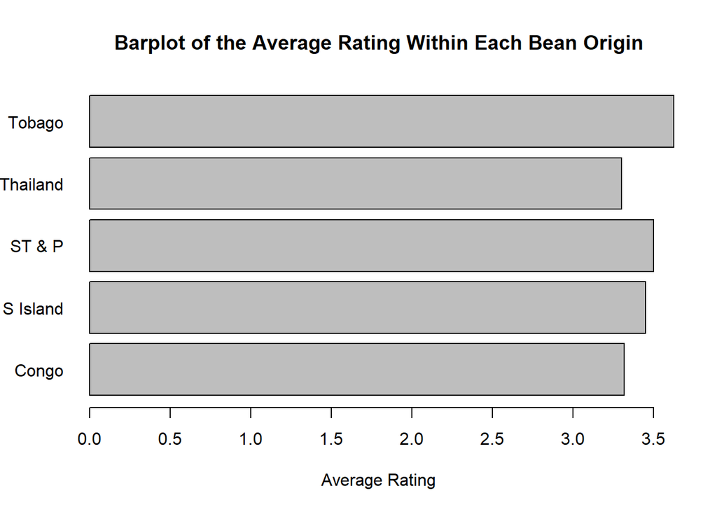

```r
#Graphical summaries
levels(origins$Bean_Origin) = c("Tobago", "ST & P", "S Island", "Congo", "Thailand")

barplot(origins$Average_Rating ~ levels(origins$Bean_Origin),
        main = 'Barplot of the Average Rating Within Each Bean Origin',
        xlab = 'Average Rating',
        ylab = '',
        horiz = TRUE,
        las = 1)
```

## Investigation of the Top 5 Companies

```r
#Creating summaries
company = choco %>%
  select(Company, Rating) %>%
  group_by(Company) %>%
  summarise(Average_Rating = mean(Rating)) %>%
  arrange(desc(Average_Rating)) %>%
  top_n(5)
#Numerical summaries
company
```

```
## # A tibble: 5 x 2
##   Company                              Average_Rating
##   <chr>                                         <dbl>
## 1 Tobago Estate (Pralus)                         4
## 2 Heirloom Cacao Preservation (Zokoko)           3.88
## 3 Ocelot                                         3.88
## 4 Matale                                         3.81
## 5 Patric                                         3.79
```

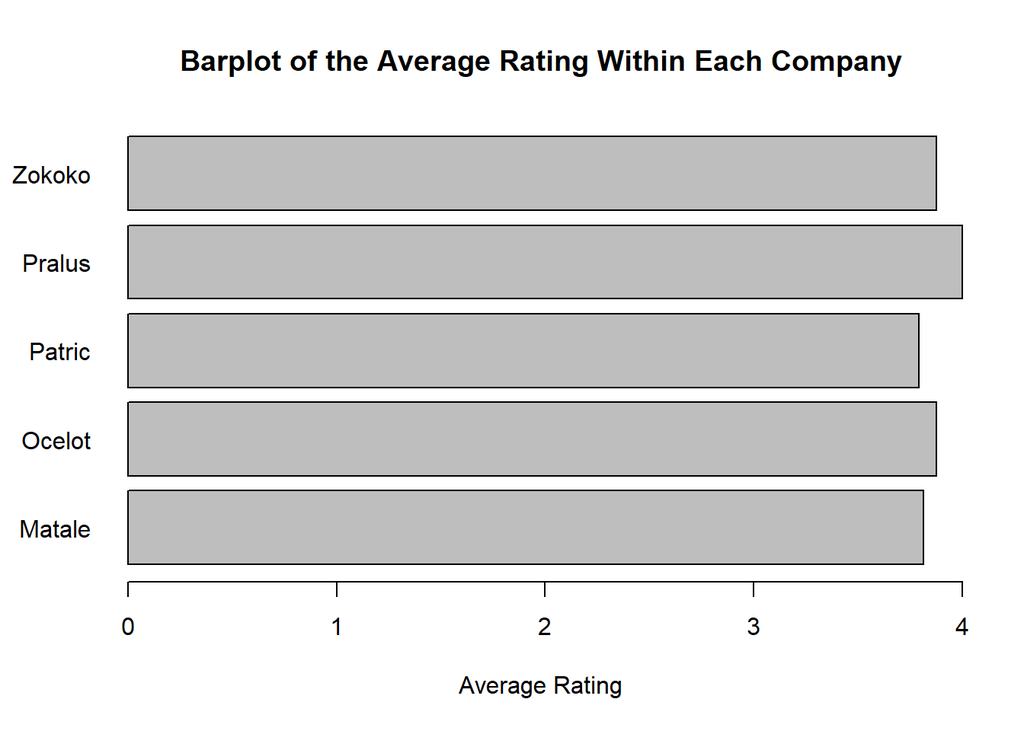

```r
#Graphical summaries
levels(company$Company) = c("Pralus", "Zokoko", "Ocelot", "Matale", "Patric")

barplot(company$Average_Rating ~ levels(company$Company),
        main = 'Barplot of the Average Rating Within Each Company',
        xlab = 'Average Rating',
        ylab = '',
        horiz = TRUE,
        las = 1)
```

From the information above, we can see that Tobago Estate (Pralus), Heirloom Cacao Preservation (Zokoko), Ocelot, Matale, and Patric have the highest average ratings among all other companies. Pralus has a perfect mean rating (4.0) and Patric has mean rating of 3.79.